# Predicting binomial and multinomial classes using semantic fingerprints, FactoMineR and glmnet

Jasper Ginn

2018-05-15

In this short vignette, I’ll demonstrate a simple usecase for Cortical’s semantic folding API on textual data. We will use a subset of the Reuters21578 dataset, which is available through the `tm.corpus.Reuters21578` library, to predict whether an article belongs to one of several classes.

```r
# Clean wd
rm(list=ls())
# Load data
data("fps_train")
data("fps_test")

# Unpack
train_lbls_b <- fps_train$label_binomial
train_lbls_m <- fps_train$label_multinomial
fps_train <- fps_train$fingerprints

test_lbls_b <- fps_test$label_binomial
test_lbls_m <- fps_test$label_multinomial
fps_test <- fps_test$fingerprints
```

We can plot one of the articles and get its keywords to get a better understanding of the context:

```r
# Select one fingerprinted document
one <- fps_train[[1]]
print(one)
```

```
#> Document object.
#>
#>  unique id:  33a9c021-e001-4324-bd7f-fbb356f84442
#>  type:       document
#>  fingerprint:    984 positions
```

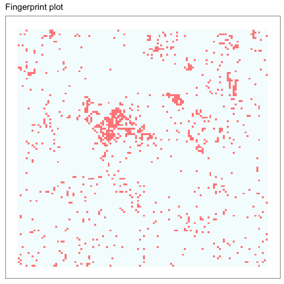

```r
# Plot
plot(one)
```

Documents can be fingerprinted in batch using `do_fingerprint_document()`. `FinTxtUtils` contains a `Collection` class that is useful for inspecting multiple documents.

```r
# Turn fingerprints into Collection
col_train <- Collection(fps_train)
col_test <- Collection(fps_test)
```

We can look at the intensity of each position as a way to see whether there is much overlap in the fingerprint positions. The intensity of a group of fingerprinted positions is simply the times a position occurs in all articles divided by the total number of fingerprint positions that are not 0.

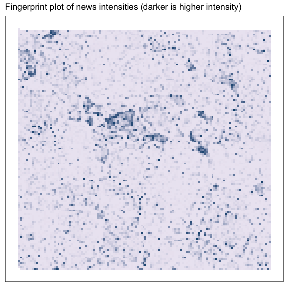

```r
# Plot intensity
plot(col_train) # Article fingerprints are very similar. This is not surprising given that we picked out articles about natural resources
```

There seems to be a lot of overlap in several areas.

We can plot separate fingerprints for each category:

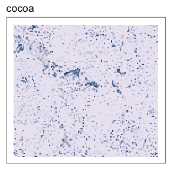

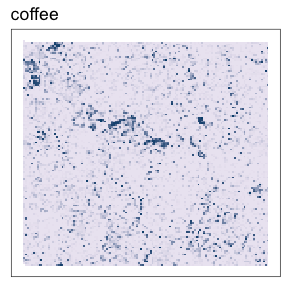

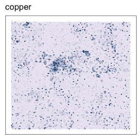

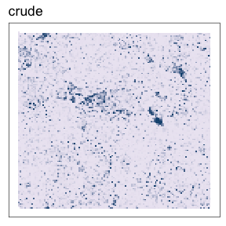

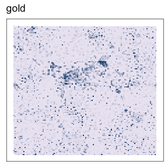

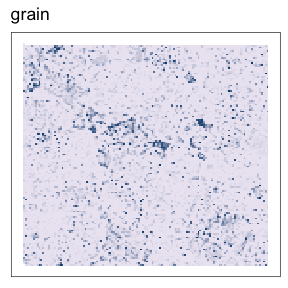

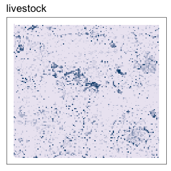

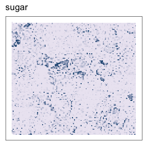

```r
cats <- levels(train_lbls_m)
# For each, make a collection and plot
catplots <- purrr::map(cats, function(x) {
  index <- which(train_lbls_m == x)
  col <- Collection(fps_train[index])
  plot(col) +
    ggtitle(x)
})

for(catplot in catplots) {
  plot(catplot)
}
```

We can train a regularized logistic regression method (a ‘lasso’) on the data. Since the data is high-dimensional (we have many more columns than observations), this is computationally expensive. However, we can first reduce the number of dimensions using Multiple Correspondence Analysis (MCA) and then use a much smaller number of variables to train the model. We first convert the collection to a sparse binary matrix:

```r
# Turn test and train into a sparse binary matrix
mtrain <- as.matrix(col_train)
mtest <- as.matrix(col_test)

mtrain[1:5, 1:8]
```

```
#> 5 x 8 sparse Matrix of class "dgCMatrix"
#>                                      p1 p2 p3 p4 p5 p6 p7 p8
#> 33a9c021-e001-4324-bd7f-fbb356f84442  .  .  .  1  .  .  1  1
#> fc10c6a4-7cfc-4e59-b23e-ef0cca69d848  .  .  .  .  .  .  .  1
#> 8c5bc5fb-f036-4b24-b7e2-24af8cc78e3b  .  .  .  .  .  .  1  1
#> 25b7cc36-78cd-43bf-9fc5-c0d782057850  .  .  .  .  .  .  .  1
#> 1fbd55a9-a99f-4c0d-9f50-c833b007c1a6  .  .  .  .  .  .  .  1
```

To do this, we have to remove all fingerprint positions that do not occur (have a value of 0) in the training data. We do this because, should these positions exist in unseen data, we cannot predict the rotation properly.

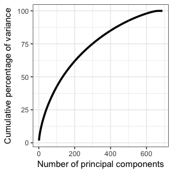

```r
# Remove columns whose sums are 0
all_zero <- which(colSums(mtrain) == 0)

# Replace
mtrain_p <- mtrain[, -all_zero]
mtest_p <- mtest[, -all_zero]

# Perform multiple correspondence analysis on sparse binary train data
library(FactoMineR)

# Multiple Correspondence Analysis on train
# We have to coerce the sparse binary matrix to a
# regular matrix
train_pca <- PCA(as.matrix(mtrain_p), ncp = ncol(mtrain_p), graph = FALSE)

# Predict on test
test_pca <- predict(train_pca, as.matrix(mtest_p))$coord

# Plot PCA (variance explained)
plotPCA <- function(eigenValue.df) {
  ggplot(data.frame(x=1:nrow(eigenValue.df),
                    y=eigenValue.df[,3]), aes(x=x, y=y)) +
    geom_line(size = 1.2) +
    theme_bw() +
    scale_x_continuous(name = "Number of principal components") +
    scale_y_continuous(name = "Cumulative percentage of variance")
}
# Plot
plotPCA(train_pca$eig)
```

For the binomial case (two test labels), we only need k=10 principal components to train a good model. In the multinomial case, we need about k=100. (you probably want to test this using cross-validation on your own data).

```r
# Number of princomp
k = 10

# Train glmnet model (binomial)
suppressPackageStartupMessages(library(glmnet))
# Train model
mod_train_binom <- cv.glmnet(x=data.matrix(train_pca$ind$coord[,1:k]),
                              y=train_lbls_b, family = "binomial")

# Predict
pred_class_b <- factor(
  predict(mod_train_binom, train_pca$ind$coord[,1:k], type="class")
, levels = c("other", "crude")
)

# Confusion matrix
caret::confusionMatrix(pred_class_b, train_lbls_b, positive = "crude")
```

```
#> Confusion Matrix and Statistics
#>
#>           Reference
#> Prediction other crude
#>      other   420    11
#>      crude     4   255
#>
#>                Accuracy : 0.9783
#>                  95% CI : (0.9644, 0.9878)
#>     No Information Rate : 0.6145
#>     P-Value [Acc > NIR] : <2e-16
#>
#>                   Kappa : 0.9539
#>  Mcnemar's Test P-Value : 0.1213
#>
#>             Sensitivity : 0.9586
#>             Specificity : 0.9906
#>          Pos Pred Value : 0.9846
#>          Neg Pred Value : 0.9745
#>              Prevalence : 0.3855
#>          Detection Rate : 0.3696
#>    Detection Prevalence : 0.3754
#>       Balanced Accuracy : 0.9746
#>
#>        'Positive' Class : crude
#>
```

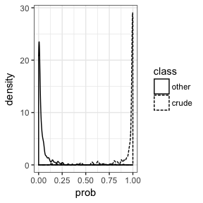

```r
k = 10
library(ggplot2)
plot_df <- data_frame(
  "prob" = predict(mod_train_binom, train_pca$ind$coord[,1:k], type="response")[,1],
  "class" = train_lbls_b,
  "class_pred" = pred_class_b
)

# Plot double-density plot for binomial case
ggplot(plot_df, aes(x= prob, group = class, linetype=class)) +
  geom_density() +
  theme_bw()
```

Using multinomial labels:

```r
# Number of components
k <- 100

# Model
mod_train_multi <- cv.glmnet(x=data.matrix(train_pca$ind$coord[,1:k]),
                              y=train_lbls_m, family = "multinomial")

# Predict
pred_class_m <- factor(
  predict(mod_train_multi, train_pca$ind$coord[,1:k], type="class"),
  levels = levels(train_lbls_m)
)

# Confusion matrix
caret::confusionMatrix(pred_class_m, train_lbls_m)
```

```
#> Confusion Matrix and Statistics
#>
#>            Reference
#> Prediction  cocoa coffee copper crude gold grain livestock sugar
#>   cocoa        42      1      0     0    0     0         0     0
#>   coffee        1     94      1     0    0     1         1     0
#>   copper        0      0     36     0    0     0         0     0
#>   crude         0      0      3   266    2     1         0     1
#>   gold          0      0      1     0   82     0         0     0
#>   grain         2      0      0     0    0    36         1     1
#>   livestock     0      0      0     0    0     0        13     0
#>   sugar         1      2      0     0    0     3         1    97
#>
#> Overall Statistics
#>
#>                Accuracy : 0.9652
#>                  95% CI : (0.9487, 0.9776)
#>     No Information Rate : 0.3855
#>     P-Value [Acc > NIR] : < 2.2e-16
#>
#>                   Kappa : 0.9554
#>  Mcnemar's Test P-Value : NA
#>
#> Statistics by Class:
#>
#>                      Class: cocoa Class: coffee Class: copper Class: crude
#> Sensitivity               0.91304        0.9691       0.87805       1.0000
#> Specificity               0.99845        0.9933       1.00000       0.9835
#> Pos Pred Value            0.97674        0.9592       1.00000       0.9744
#> Neg Pred Value            0.99382        0.9949       0.99235       1.0000
#> Prevalence                0.06667        0.1406       0.05942       0.3855
#> Detection Rate            0.06087        0.1362       0.05217       0.3855
#> Detection Prevalence      0.06232        0.1420       0.05217       0.3957
#> Balanced Accuracy         0.95575        0.9812       0.93902       0.9917
#>                      Class: gold Class: grain Class: livestock
#> Sensitivity               0.9762      0.87805          0.81250
#> Specificity               0.9983      0.99384          1.00000
#> Pos Pred Value            0.9880      0.90000          1.00000
#> Neg Pred Value            0.9967      0.99231          0.99557
#> Prevalence                0.1217      0.05942          0.02319
#> Detection Rate            0.1188      0.05217          0.01884
#> Detection Prevalence      0.1203      0.05797          0.01884
#> Balanced Accuracy         0.9873      0.93594          0.90625
#>                      Class: sugar
#> Sensitivity                0.9798
#> Specificity                0.9882
#> Pos Pred Value             0.9327
#> Neg Pred Value             0.9966
#> Prevalence                 0.1435
#> Detection Rate             0.1406
#> Detection Prevalence       0.1507
#> Balanced Accuracy          0.9840
```

In both cases, we obtain a good result.

On test set:

```r
# Number of components
k <- 100

# Predict
pred_class_m_t <- factor(
  predict(mod_train_multi, test_pca[,1:k], type="class"),
  levels = levels(test_lbls_m)
)

# Confusion matrix
caret::confusionMatrix(pred_class_m_t, test_lbls_m)
```

```
#> Confusion Matrix and Statistics
#>
#>            Reference
#> Prediction  cocoa coffee copper crude gold grain livestock sugar
#>   cocoa         6      0      0     0    0     0         0     0
#>   coffee        1     16      0     0    0     0         0     1
#>   copper        0      0     10     0    0     0         0     0
#>   crude         1      0      3    88    0     1         2     1
#>   gold          0      1      0     0   15     0         0     0
#>   grain         0      0      0     0    0     2         0     0
#>   livestock     0      0      0     0    0     0         1     0
#>   sugar         1      0      0     0    0     1         1    34
#>
#> Overall Statistics
#>
#>                Accuracy : 0.9247
#>                  95% CI : (0.8769, 0.9582)
#>     No Information Rate : 0.4731
#>     P-Value [Acc > NIR] : < 2.2e-16
#>
#>                   Kappa : 0.8918
#>  Mcnemar's Test P-Value : NA
#>
#> Statistics by Class:
#>
#>                      Class: cocoa Class: coffee Class: copper Class: crude
#> Sensitivity               0.66667       0.94118       0.76923       1.0000
#> Specificity               1.00000       0.98817       1.00000       0.9184
#> Pos Pred Value            1.00000       0.88889       1.00000       0.9167
#> Neg Pred Value            0.98333       0.99405       0.98295       1.0000
#> Prevalence                0.04839       0.09140       0.06989       0.4731
#> Detection Rate            0.03226       0.08602       0.05376       0.4731
#> Detection Prevalence      0.03226       0.09677       0.05376       0.5161
#> Balanced Accuracy         0.83333       0.96467       0.88462       0.9592
#>                      Class: gold Class: grain Class: livestock
#> Sensitivity              1.00000      0.50000         0.250000
#> Specificity              0.99415      1.00000         1.000000
#> Pos Pred Value           0.93750      1.00000         1.000000
#> Neg Pred Value           1.00000      0.98913         0.983784
#> Prevalence               0.08065      0.02151         0.021505
#> Detection Rate           0.08065      0.01075         0.005376
#> Detection Prevalence     0.08602      0.01075         0.005376
#> Balanced Accuracy        0.99708      0.75000         0.625000
#>                      Class: sugar
#> Sensitivity                0.9444
#> Specificity                0.9800
#> Pos Pred Value             0.9189
#> Neg Pred Value             0.9866
#> Prevalence                 0.1935
#> Detection Rate             0.1828
#> Detection Prevalence       0.1989
#> Balanced Accuracy          0.9622
```